[figure not shown]

Prof. Carlos Andrés Ferrero

# Mineração de Dados

## Aprendizado Simbólico: Indução de Árvores de Decisão

## Conteúdo

- Introdução
- Algoritmo Geral
- Running Example
- Exercícios

## Introduçao

- Árvores de Decisão (AD) são uma das técnicas mais populares de mineração de dados.
- As AD consistem em um conjunto de *nós internos* e *nós folhas* que estão organizados hierárquicamente.

[figure not shown]

- Essa estrutura permite organizar o processo de decisão.
- Um exemplo, poderia ser uma árvore de decisão para decidir se ir jogar tênis ou não, baseado em alguns atributos climáticos.

[figure not shown]

- Algumas vantagens das árvores de decisão:
  - O conhecimento é explícito e interpretável.
  - O processo de tomada de decisão é, além de entendível, explicável.
  - Podem ser representados por meio de símbolos usando a forma **se/então**, por isso é chamado de modelo simbólico.

### Principais Algoritmos

- Os algoritmos de indução de classificadores que representam o conhecimento adquirido por meio de uma Árvores de Decisão, pertencem a uma família de algoritmos chamados TDIDT (Top Down Induction of Decision Trees).
- Existe uma literatura extensa sobre algoritmos clássicos e adaptadções de algoritmos, mas alguns dos principais:
  - ID3 (Iterative Dichotomiser 3)
    - Proposto por Quinlan em 1986
    - Suporta atributos discretos e classe também discreta.
  - C4.5
    - Proposto por Quinlan em 1993
    - Suporta atributos discretos e contínuos, e classe discreta.
  - M5
    - Proposto por Quinlan em 1992
    - Suporta atributos discretos e contínuos, e classe numérica
    - Neste caso, chamam-se árvores de regressão

## Algoritmo Geral

- A idéia geral do algoritmo consiste em dividir o conjunto de dados sucessivamente até que todos nós folha sejam puros.
- Método $AD(X)$
  1. Se todos os exemplos em $X$ são da mesma classe cria-se uma nó folha para essa classe;
  2. Caso contrário:
  1. Mede-se a **qualidade** de todos os atributos;
  2. Se nenhum atributo consegue melhorar a organização do conjunto $X$ então cria-se um nó folha para a classe **mais frequênte**;
  3. Caso contrário:
  1. Escolhe o **melhor atributo** $A$ para $X$;
  2. Cria-se um nó interno de decisão baseado em $A$;
  3. Divide-se o conjunto de dados de acordo com os valores de $A$ em subconjuntos $X_j$;
  4. A partir do nó de decisão cria-se uma aresta para cada valor de $A$ e associa-se cada $X_j$ a uma aresta;
  5. Para cada conjunto $X_j$ executa-se o método $AD(X_j)$;

## Running Example

```r
library(data.table)
dt <- fread("data/playtennis.txt", stringsAsFactor=T)[,-1]
dt
```

| Outlook | Temp | Humidity | Wind | PlayTennis |
| --- | --- | --- | --- | --- |
| Sunny | Hot | High | Weak | No |
| Sunny | Hot | High | Strong | No |
| Overcast | Hot | High | Weak | Yes |
| Rain | Mild | High | Weak | Yes |
| Rain | Cool | Normal | Weak | Yes |
| Rain | Cool | Normal | Strong | No |
| Overcast | Cool | Normal | Strong | Yes |
| Sunny | Mild | High | Weak | No |
| Sunny | Cool | Normal | Weak | Yes |
| Rain | Mild | Normal | Weak | Yes |
| Sunny | Mild | Normal | Strong | Yes |
| Overcast | Mild | High | Strong | Yes |
| Overcast | Hot | Normal | Weak | Yes |
| Rain | Mild | High | Strong | No |

Método $AD$ para $X$

- Esse conjunto de dados possui exemplos de ambas as classes, então vamos medir a qualidade de seus atributos, usando o ganho de informação.

```r
library(FSelector)
information.gain(PlayTennis ~ Outlook + Temp + Humidity + Wind, data = dt, unit="log2")
```

|  | attr_importance |
| --- | --- |
| Outlook | 0.24674982 |
| Temp | 0.02922257 |
| Humidity | 0.15183550 |
| Wind | 0.04812703 |

- Temos atributos que produzem ganho de informação, então escolhemos como melhor atributo, aquele que tem o maior ganho.
- O atributo com maior ganho de informação é o atributo **Outlook**, portanto criamos um nó de decisão para esse atributo. E também um conjunto de dados $X_j$ para cada valor do atributo Outlook: Sunny, Overcast, e Rain.
- Árvore de Decisão Parcial

[figure not shown]

```r
dt.outlook.overcast <- dt[Outlook == "Overcast"] # X_1
dt.outlook.sunny    <- dt[Outlook == "Sunny"] # X_2
dt.outlook.rain     <- dt[Outlook == "Rain"] # X_3
```

- Observem os subconjuntos de dados

```r
dt.outlook.overcast
```

| Outlook | Temp | Humidity | Wind | PlayTennis |
| --- | --- | --- | --- | --- |
| Overcast | Hot | High | Weak | Yes |
| Overcast | Cool | Normal | Strong | Yes |
| Overcast | Mild | High | Strong | Yes |
| Overcast | Hot | Normal | Weak | Yes |

```r
dt.outlook.rain
```

| Outlook | Temp | Humidity | Wind | PlayTennis |
| --- | --- | --- | --- | --- |
| Rain | Mild | High | Weak | Yes |
| Rain | Cool | Normal | Weak | Yes |
| Rain | Cool | Normal | Strong | No |
| Rain | Mild | Normal | Weak | Yes |
| Rain | Mild | High | Strong | No |

```r
dt.outlook.sunny
```

| Outlook | Temp | Humidity | Wind | PlayTennis |
| --- | --- | --- | --- | --- |
| Sunny | Hot | High | Weak | No |
| Sunny | Hot | High | Strong | No |
| Sunny | Mild | High | Weak | No |
| Sunny | Cool | Normal | Weak | Yes |
| Sunny | Mild | Normal | Strong | Yes |

Agora temos que aplicar o mesmo método $AD$ para cada um dos subconjuntos $X_1$, $X_2$ e $X_3$.

Método $AD$ para $X_1$

```r
dt.outlook.overcast
```

| Outlook | Temp | Humidity | Wind | PlayTennis |
| --- | --- | --- | --- | --- |
| Overcast | Hot | High | Weak | Yes |
| Overcast | Cool | Normal | Strong | Yes |
| Overcast | Mild | High | Strong | Yes |
| Overcast | Hot | Normal | Weak | Yes |

- Como todos os exemplos do conjunto de dados $X_1$ são da mesma classe, criamos então o nó folha com essa classe.
- Árvore de Decisão Parcial

[figure not shown]

```r
dt.outlook.rain
```

| Outlook | Temp | Humidity | Wind | PlayTennis |
| --- | --- | --- | --- | --- |
| Rain | Mild | High | Weak | Yes |
| Rain | Cool | Normal | Weak | Yes |
| Rain | Cool | Normal | Strong | No |
| Rain | Mild | Normal | Weak | Yes |
| Rain | Mild | High | Strong | No |

- Como temos exemplos em $X_2$ de classes diferentes então precisamos medir a qualidade dos atributos para verificar se algum atributo permite melhorar a organização dos dados

```r
information.gain(PlayTennis ~ Outlook + Temp + Humidity + Wind, data = dt.outlook.rain, unit="log2")
```

|  | attr_importance |
| --- | --- |
| Outlook | 0.00000000 |
| Temp | 0.01997309 |
| Humidity | 0.01997309 |
| Wind | 0.97095059 |

- O atributo **Wind** apresentou o maior ganho de informação, portanto é o atributo escolhido para fazer um nó de decisão.
- Criamos um conjunto de dados $X_{2,j}$ para cada valor do atributo Wind: Strong e Weak.
- Árvore de Decisão Parcial

[figure not shown]

```r
dt.outlook.rain.wind.strong <- dt.outlook.rain[Wind == "Strong"] # X_{2,1}
dt.outlook.rain.wind.weak   <- dt.outlook.rain[Wind == "Weak"] # X_{2,2}
```

- Observamos os conjuntos de dados

```r
dt.outlook.rain.wind.strong
```

| Outlook | Temp | Humidity | Wind | PlayTennis |
| --- | --- | --- | --- | --- |
| Rain | Cool | Normal | Strong | No |
| Rain | Mild | High | Strong | No |

```r
dt.outlook.rain.wind.weak
```

| Outlook | Temp | Humidity | Wind | PlayTennis |
| --- | --- | --- | --- | --- |
| Rain | Mild | High | Weak | Yes |
| Rain | Cool | Normal | Weak | Yes |
| Rain | Mild | Normal | Weak | Yes |

Temos que aplicar o mesmo método $AD$ para cada um dos subconjuntos $X_{2,1}$ e $X_{2,2}$.

Método $AD$ para $X_{2,1}$

```r
dt.outlook.rain.wind.strong
```

| Outlook | Temp | Humidity | Wind | PlayTennis |
| --- | --- | --- | --- | --- |
| Rain | Cool | Normal | Strong | No |
| Rain | Mild | High | Strong | No |

- Como temos exemplos apenas da classe $PlayTennis = No$ então criamos um nó folha para essa classe.
- Árvore de Decisão Parcial

[figure not shown]

Método $AD$ para $X_{2,2}$

```r
dt.outlook.rain.wind.weak
```

| Outlook | Temp | Humidity | Wind | PlayTennis |
| --- | --- | --- | --- | --- |
| Rain | Mild | High | Weak | Yes |
| Rain | Cool | Normal | Weak | Yes |
| Rain | Mild | Normal | Weak | Yes |

- Este conjunto de dados também possui exemplos de uma classe, $PlayTennis = Yes$, portanto temos que criar um nó folha para essa classe.
- Árvore de Decisão Parcial

[figure not shown]

Método $AD$ para $X_{3}$

```r
dt.outlook.sunny
```

| Outlook | Temp | Humidity | Wind | PlayTennis |
| --- | --- | --- | --- | --- |
| Sunny | Hot | High | Weak | No |
| Sunny | Hot | High | Strong | No |
| Sunny | Mild | High | Weak | No |
| Sunny | Cool | Normal | Weak | Yes |
| Sunny | Mild | Normal | Strong | Yes |

- Este conjunto de dados possui exemplos de ambas as classes, então vamos calcular a qualidade dos atributos, para verificar se existe algum atributo que permita organizar melhor os dados.

```r
information.gain(PlayTennis ~ Outlook + Temp + Humidity + Wind, data = dt.outlook.sunny, unit="log2")
```

|  | attr_importance |
| --- | --- |
| Outlook | 0.00000000 |
| Temp | 0.57095059 |
| Humidity | 0.97095059 |
| Wind | 0.01997309 |

- Verificamos que o atributo que possui melhor qualidade é **Humidity** e escolhemos ele como o nosso melhor atributo.
- Criamos um nó de decisão para o atributo **Humidity**
- Criamos um conjunto de dados $X_{3,j}$ para cada valor do atributo Humdity: High e Normal.
- Árvore de Decisão Parcial

[figure not shown]

```r
dt.outlook.sunny.humidity.high <- dt.outlook.sunny[Humidity == "High"] # X_{3,1}
dt.outlook.sunny.humidity.normal <- dt.outlook.sunny[Humidity == "Normal"] # X_{3,2}
```

- Observamos os subconjuntos de dados

```r
dt.outlook.sunny.humidity.high
```

| Outlook | Temp | Humidity | Wind | PlayTennis |
| --- | --- | --- | --- | --- |
| Sunny | Hot | High | Weak | No |
| Sunny | Hot | High | Strong | No |
| Sunny | Mild | High | Weak | No |

```r
dt.outlook.sunny.humidity.normal
```

| Outlook | Temp | Humidity | Wind | PlayTennis |
| --- | --- | --- | --- | --- |
| Sunny | Cool | Normal | Weak | Yes |
| Sunny | Mild | Normal | Strong | Yes |

Método $AD$ para $X_{3,1}$

```r
dt.outlook.sunny.humidity.high
```

| Outlook | Temp | Humidity | Wind | PlayTennis |
| --- | --- | --- | --- | --- |
| Sunny | Hot | High | Weak | No |
| Sunny | Hot | High | Strong | No |
| Sunny | Mild | High | Weak | No |

- Este conjunto de dados também possui exemplos de uma classe, $PlayTennis = No$, portanto temos que criar um nó folha para essa classe.
- Árvore de Decisão Parcial

[figure not shown]

Método $AD$ para $X_{3,2}$

```r
dt.outlook.sunny.humidity.normal
```

| Outlook | Temp | Humidity | Wind | PlayTennis |
| --- | --- | --- | --- | --- |
| Sunny | Cool | Normal | Weak | Yes |
| Sunny | Mild | Normal | Strong | Yes |

- Este conjunto de dados também possui exemplos de uma classe, $PlayTennis = Yes$, portanto temos que criar um nó folha para essa classe.
- Árvore de Decisão Final

[figure not shown]

## Indução de Árvores de Decisão usando R

```r
library(RWeka)
{ # Para não mostrar os comentarios
    WPM("refresh-cache");
    WPM("list-packages", "available");
    WPM("install-package", "simpleEducationalLearningSchemes");
    WPM("load-package", "simpleEducationalLearningSchemes")
}
ID3 <- make_Weka_classifier("weka/classifiers/trees/Id3")
```

[output not shown]

### Algoritmo ID3

```r
model.ID3 <- ID3(PlayTennis ~ ., data = dt)
model.ID3
```

```
Id3


Outlook = Overcast: Yes
Outlook = Rain
|  Wind = Strong: No
|  Wind = Weak: Yes
Outlook = Sunny
|  Humidity = High: No
|  Humidity = Normal: Yes
```

### Algoritmo C4.5 (J48 Implementation)

```r
model.J48 <- J48(PlayTennis ~ ., data = dt)
model.J48
```

```
J48 pruned tree
------------------

Outlook = Overcast: Yes (4.0)
Outlook = Rain
|   Wind = Strong: No (2.0)
|   Wind = Weak: Yes (3.0)
Outlook = Sunny
|   Humidity = High: No (3.0)
|   Humidity = Normal: Yes (2.0)

Number of Leaves  : 	5

Size of the tree : 	8
```

## Árvores de Decisão para Atributos Contínuos e Classe Discreta

### Conjunto de Dados Iris

```r
head(iris)
```

| Sepal.Length | Sepal.Width | Petal.Length | Petal.Width | Species |
| --- | --- | --- | --- | --- |
| 5.1 | 3.5 | 1.4 | 0.2 | setosa |
| 4.9 | 3.0 | 1.4 | 0.2 | setosa |
| 4.7 | 3.2 | 1.3 | 0.2 | setosa |
| 4.6 | 3.1 | 1.5 | 0.2 | setosa |
| 5.0 | 3.6 | 1.4 | 0.2 | setosa |
| 5.4 | 3.9 | 1.7 | 0.4 | setosa |

```r
model.J48 <- J48(Species ~ . ,  data = iris )
model.J48
```

```
J48 pruned tree
------------------

Petal.Width <= 0.6: setosa (50.0)
Petal.Width > 0.6
|   Petal.Width <= 1.7
|   |   Petal.Length <= 4.9: versicolor (48.0/1.0)
|   |   Petal.Length > 4.9
|   |   |   Petal.Width <= 1.5: virginica (3.0)
|   |   |   Petal.Width > 1.5: versicolor (3.0/1.0)
|   Petal.Width > 1.7: virginica (46.0/1.0)

Number of Leaves  : 	5

Size of the tree : 	9
```

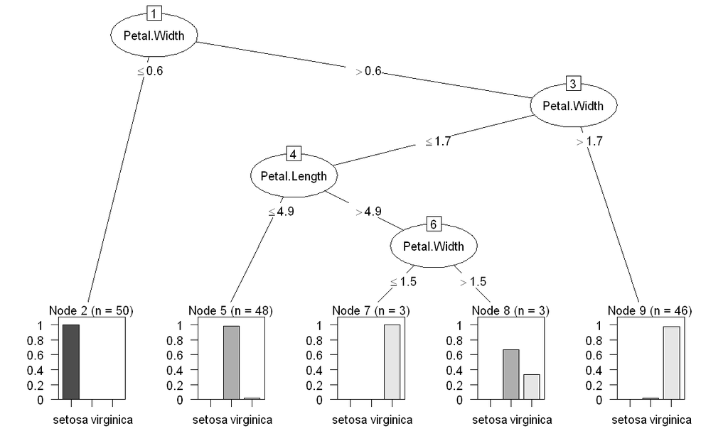

```r
options(repr.plot.width=10, repr.plot.height=6)
plot(model.J48)
```

- Podemos observar os atributos numéricos foram separados de forma binária.
- Os subconjuntos de dados $X_j$ correspondem aos exemplos que possuem atributo $A$ maior ou menor do que um valor $x_{sp}$, comumente chamado de *split point*.
- Esse *split point* é encontrado fazendo alguns testes no conjunto de dados.
- Esses testes tem como objetivo dividir o conjunto de dados em duas partes, baseado em um atributo $A$ aqueles que são maiores do que o *split plont* $x_{sp}$ e aqueles que são maiores do que o *split point*.
- Considere o seguinte conjunto de dados, que é uma amostra de 15 exemplos do dataset *iris*.

```r
set.seed(1)
dt <- data.table(iris)[sample(1:nrow(iris),size=15,replace=F)]
dt
```

| Sepal.Length | Sepal.Width | Petal.Length | Petal.Width | Species |
| --- | --- | --- | --- | --- |
| 5.1 | 3.4 | 1.5 | 0.2 | setosa |
| 5.7 | 2.8 | 4.5 | 1.3 | versicolor |
| 5.4 | 3.0 | 4.5 | 1.5 | versicolor |
| 6.3 | 2.8 | 5.1 | 1.5 | virginica |
| 4.7 | 3.2 | 1.6 | 0.2 | setosa |
| 7.4 | 2.8 | 6.1 | 1.9 | virginica |
| 6.3 | 3.4 | 5.6 | 2.4 | virginica |
| 5.6 | 2.7 | 4.2 | 1.3 | versicolor |
| 5.5 | 2.5 | 4.0 | 1.3 | versicolor |
| 4.4 | 2.9 | 1.4 | 0.2 | setosa |
| 5.2 | 3.4 | 1.4 | 0.2 | setosa |
| 4.8 | 3.4 | 1.9 | 0.2 | setosa |
| 5.8 | 2.7 | 5.1 | 1.9 | virginica |
| 6.9 | 3.1 | 4.9 | 1.5 | versicolor |
| 6.5 | 3.0 | 5.8 | 2.2 | virginica |

- Vamos analisar o atributo *Petal.Width*

```r
dt[,.(Petal.Width,Species)]
```

| Petal.Width | Species |
| --- | --- |
| 0.2 | setosa |
| 1.3 | versicolor |
| 1.5 | versicolor |
| 1.5 | virginica |
| 0.2 | setosa |
| 1.9 | virginica |
| 2.4 | virginica |
| 1.3 | versicolor |
| 1.3 | versicolor |
| 0.2 | setosa |
| 0.2 | setosa |
| 0.2 | setosa |
| 1.9 | virginica |
| 1.5 | versicolor |
| 2.2 | virginica |

```r
dt.aux <- dt[,.(Petal.Width,Species)][order(Petal.Width)]
dt.aux
```

| Petal.Width | Species |
| --- | --- |
| 0.2 | setosa |
| 0.2 | setosa |
| 0.2 | setosa |
| 0.2 | setosa |
| 0.2 | setosa |
| 1.3 | versicolor |
| 1.3 | versicolor |
| 1.3 | versicolor |
| 1.5 | versicolor |
| 1.5 | virginica |
| 1.5 | versicolor |
| 1.9 | virginica |
| 1.9 | virginica |
| 2.2 | virginica |
| 2.4 | virginica |

- Vários split points poderiam ser testados, vamos nos deter apenas a analisar aqueles candidatos a maximizar o ganho de informação.
- Os candidatos a split point nesse conjunto de dados são:
  - Entre 0.2 e 1.3, onde o $x_{sp} = (0.2+1.3)/2 = 0.75$
  - Entre 1.3 e 1.5, onde o $x_{sp} = (1.3+1.5)/2 = 1.40$
  - Entre 1.5 e 1.9, onde o $x_{sp} = (1.5+1.9)/2 = 1.70$

```r
dt.aux$`Split.Point=0.75` <- ifelse(dt.aux$Petal.Width < 0.75, "menores","maiores")
dt.aux$`Split.Point=1.40` <- ifelse(dt.aux$Petal.Width < 1.40, "menores","maiores")
dt.aux$`Split.Point=1.70` <- ifelse(dt.aux$Petal.Width < 1.70, "menores","maiores")
dt.aux
```

| Petal.Width | Species | Split.Point=0.75 | Split.Point=1.40 | Split.Point=1.70 |
| --- | --- | --- | --- | --- |
| 0.2 | setosa | menores | menores | menores |
| 0.2 | setosa | menores | menores | menores |
| 0.2 | setosa | menores | menores | menores |
| 0.2 | setosa | menores | menores | menores |
| 0.2 | setosa | menores | menores | menores |
| 1.3 | versicolor | maiores | menores | menores |
| 1.3 | versicolor | maiores | menores | menores |
| 1.3 | versicolor | maiores | menores | menores |
| 1.5 | versicolor | maiores | maiores | menores |
| 1.5 | virginica | maiores | maiores | menores |
| 1.5 | versicolor | maiores | maiores | menores |
| 1.9 | virginica | maiores | maiores | maiores |
| 1.9 | virginica | maiores | maiores | maiores |
| 2.2 | virginica | maiores | maiores | maiores |
| 2.4 | virginica | maiores | maiores | maiores |

- Calculando o ganho de informação das três divisões:

```r
information.gain(Species ~ ., data = dt.aux[,-1], unit="log2" )
```

|  | attr_importance |
| --- | --- |
| Split.Point=0.75 | 0.9182958 |
| Split.Point=1.40 | 0.6731414 |
| Split.Point=1.70 | 0.5959980 |

$$ x_{sp} = arg\,max_{value \in A} \; IG(X,A,value) $$

$$ IG(X,A) = IG(X,A,x_{sp})$$

### Exercício

- Considere o conjunto de dados Iris de 15 exemplos, usado na aula, e para cada um dos atributos Petal.Width, Petal.Length, Sepal.Wdith e Sepal.Length:
  - Encontre os possíveis candidatos a split point;
  - Calcule o ganho de informação para cada split point;
  - Encontre o split point com maior ganho de informação;
  - Verifique qual atributo apresenta o melhor ganho de informação.

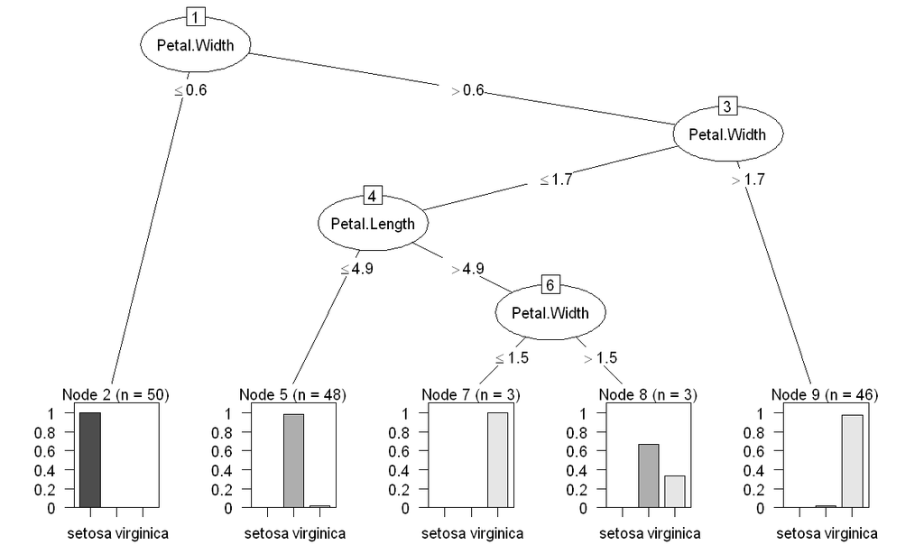

```r
plot(model.J48)
```

### Algoritmos ID3 e J48

- A complexidade desses algoritmos é da ordem $O(n \times m^2)$, onde $n$ é o número de exemplos e $m$ é o número de atributos.
- Os algoritmos são gulosos (*greedy*), pois a cada iteração eles escolhem um atributo de forma gulosa, baseado numa medida importância de atributos, que só olha para o estado atual do problema.
- O algoritmo não é ótimo, pois não explora todas as possíveis árvores para escolher a melhor.
- O algoritmo é completo, pois sempre contrói uma árvore, nem que seja apenas um nó raiz folha que para a classe majoritária.

### Avaliação de Modelos

- A avaliação de modelos tem como objetivo conhecer a performance de um modelo no futuro, seja de classificação ou regressão.
- Para avaliar a performance de um modelo de classificação temos várias medidas, como:
  - Acurácia de classificação
  - Erro de classificação
  - Precisão vs. Recuperação (*Precision* and *Recall*)
  - Medida F (*F-measure*)
- Para extrair essas medidas é preciso construir uma *matriz de confusão* ou *tabela de confusão*
- Seja um problema de duas classes (*postiva* P e *negativa* N) a matriz de confusão de classificação definida por:

| Classe | Predita P | Predita N |
| --- | --- | --- |
| **Observada P** | $TP$ | $FN$ |
| **Observada N** | $FP$ | $TN$ |

- onde,
  - $TP$ é *True Positive*
  - $TN$ é *True Negative*
  - $FP$ é *False Postive*
  - $FN$ é *False Negative*
- Exemplo: a avaliação de um modelo $m$ apresenta a seguinte tabela de confusão para 200 exemplos ($N = 200$):

| Classe | Predita P | Predita N |
| --- | --- | --- |
| **Observada P** | $TP=90$ | $FN=10$ |
| **Observada N** | $FP=20$ | $TN=80$ |

- Isso significa que, do total de 200 exemplos,
  - 90 exemplos da classe positiva foram classificados como positivos (corretamente)
  - 80 exemplos da classe negativa foram classificados como negativos (corretamente)
  - 10 exemplos da classe positiva foram classificados como negativos (incorretamente)
  - 20 exemplos da classe negativa foram classificados como positivos (incorretamente)
- Baseado nessa tabela de confusão podemos calcular as medidas.
- A **acurácia de classificação** consiste na proporção de exemplos classificados *corretamente* do total de exemplos.

$$ accuracy = \frac{TP + TN}{TP+TN+FP+FN} = \frac{TP + TN}{N} $$

- No exemplo, a **acurácia** do modelo $m$ é dada por:

$$ accuracy(m) = \frac{90 + 80}{200} = \frac{170}{200} = 0.85$$

- O **erro de classificação** consiste na proporção de exemplos classificados *incorretamente* do total de exemplos.

$$ error = \frac{FP + FN}{TP+TN+FP+FN} = \frac{FP + FN}{N} $$

- No exemplo, o **erro** do modelo $m$ é dado por:

$$ error(m) = \frac{20 + 10}{200} = \frac{30}{200} = 0.15 $$

- A **precisão** (*precision*) consiste na proporção de exemplos *positivos* classificados *corretamente* do total de exemplos classificados como positivos.

$$ precision = \frac{TP}{TP+FP} $$

- Pode ser entendida como a acurácia sobre os classificados como positivs, e é também chamada de Valor Preditivo Positivo.
- No exemplo, a **precisão** do modelo $m$ é dada por:

$$ precision(m) = \frac{90}{110} = 0.82 $$

$$ recall = \frac{TP}{TP+FN} $$

- Pode ser entendida como a acurácia sobre a classe positiva, e é chamada de Taxa de Verdadeiros Positivos.
- No exemplo a **recuperação** do modelo $m$ é dada por:

$$ recall(m) = \frac{90}{100} = 0.9 $$

- A partir dos valores de *precision* e *recall* é possível calcular o valor da **medida F** (*F-measure* ou também chamada de *F-score*)
- Essa medida permite balancear os valores de *precision* e *recall* calculando a média armônica de ambas as medidas.

$$ F = 2 \times \frac{precision \times recall}{precision + recall} $$

- No exemplo, a **medida F** do modelo $m$ é dada por:

$$ F = 2 \times \frac{0.82 \times 0.9}{0.82 + 0.9} = 0.86 $$

- Portanto, no exemplo apresentado os valores das medidas de avaliação foram os seguintes:

| Medida | Valor |
| --- | --- |
| **acurácia** | $0.85$ |
| **erro** | $0.15$ |
| **precisão** | $0.82$ |
| **recuperação** | $0.90$ |
| **F-measure** | $0.86$ |

### Exercício

- Suponha que um novo modelo $m'$ foi contruído com a seguinte tabela de confusão.

| Classe | Predita P | Predita N |
| --- | --- | --- |
| **Observada P** | $TP=85$ | $FN=15$ |
| **Observada N** | $FP=8$ | $TN=92$ |

- Calule os valores das 5 medidas e compare os resultados.
- Se tivesse que escolher entre esses dois modelos, qual você escolheria?

## Estratégias de Avaliação de Modelos

### Exemplo utilizando o conjunto iris completo

Avaliação usando **Trianing set**:

```r
library(RWeka)
model.J48 <- J48(Species ~ ., data = iris)
model.J48
```

```
J48 pruned tree
------------------

Petal.Width <= 0.6: setosa (50.0)
Petal.Width > 0.6
|   Petal.Width <= 1.7
|   |   Petal.Length <= 4.9: versicolor (48.0/1.0)
|   |   Petal.Length > 4.9
|   |   |   Petal.Width <= 1.5: virginica (3.0)
|   |   |   Petal.Width > 1.5: versicolor (3.0/1.0)
|   Petal.Width > 1.7: virginica (46.0/1.0)

Number of Leaves  : 	5

Size of the tree : 	9
```

```r
evaluate_Weka_classifier(model.J48, iris)
```

```
=== Summary ===

Correctly Classified Instances         147               98      %
Incorrectly Classified Instances         3                2      %
Kappa statistic                          0.97
Mean absolute error                      0.0233
Root mean squared error                  0.108
Relative absolute error                  5.2482 %
Root relative squared error             22.9089 %
Total Number of Instances              150

=== Confusion Matrix ===

  a  b  c   <-- classified as
 50  0  0 |  a = setosa
  0 49  1 |  b = versicolor
  0  2 48 |  c = virginica
```

Avaliar usando **Holdout**

```r
set.seed(1)
train.size <- round(nrow(iris) * 2/3) # 2/3 para treino
indices <- sample(1:nrow(iris), size= train.size, replace = F)
dt.train <- iris[indices,]
dt.test  <- iris[-indices,]
model.J48 <- J48(Species ~ ., dt.train)
```

```r
model.J48
```

```
J48 pruned tree
------------------

Petal.Width <= 0.6: setosa (32.0)
Petal.Width > 0.6
|   Petal.Width <= 1.6: versicolor (35.0/1.0)
|   Petal.Width > 1.6: virginica (33.0/2.0)

Number of Leaves  : 	3

Size of the tree : 	5
```

```r
evaluate_Weka_classifier(model.J48, dt.test)
```

```
=== Summary ===

Correctly Classified Instances          47               94      %
Incorrectly Classified Instances         3                6      %
Kappa statistic                          0.9101
Mean absolute error                      0.0563
Root mean squared error                  0.1966
Relative absolute error                 12.7471 %
Root relative squared error             41.8293 %
Total Number of Instances               50

=== Confusion Matrix ===

  a  b  c   <-- classified as
 18  0  0 |  a = setosa
  0 14  0 |  b = versicolor
  0  3 15 |  c = virginica
```

```r
evaluate <- evaluate_Weka_classifier(model.J48, dt.test, class = T)
round(evaluate$detailsClass,2)
```

|  | falsePositiveRate | falseNegativeRate | precision | recall | fMeasure | areaUnderROC |
| --- | --- | --- | --- | --- | --- | --- |
| setosa | 0.00 | 0.00 | 1.00 | 1.00 | 1.00 | 1.00 |
| versicolor | 0.08 | 0.00 | 0.82 | 1.00 | 0.90 | 0.96 |
| virginica | 0.00 | 0.17 | 1.00 | 0.83 | 0.91 | 0.96 |

Avaliar usando **10-folds cross-validation**:

```r
model.J48 <- J48(Species ~ ., iris)
evaluate_Weka_classifier(model.J48, iris, numFolds = 10, seed = 1)
```

```
=== 10 Fold Cross Validation ===

=== Summary ===

Correctly Classified Instances         144               96      %
Incorrectly Classified Instances         6                4      %
Kappa statistic                          0.94
Mean absolute error                      0.035
Root mean squared error                  0.1586
Relative absolute error                  7.8705 %
Root relative squared error             33.6353 %
Total Number of Instances              150

=== Confusion Matrix ===

  a  b  c   <-- classified as
 49  1  0 |  a = setosa
  0 47  3 |  b = versicolor
  0  2 48 |  c = virginica
```

```r
evaluate <- evaluate_Weka_classifier(model.J48, iris, numFolds = 10, class = T, seed = 1)
round(evaluate$detailsClass,2)
```

|  | falsePositiveRate | falseNegativeRate | precision | recall | fMeasure | areaUnderROC |
| --- | --- | --- | --- | --- | --- | --- |
| setosa | 0.00 | 0.02 | 1.00 | 0.98 | 0.99 | 0.99 |
| versicolor | 0.03 | 0.06 | 0.94 | 0.94 | 0.94 | 0.95 |
| virginica | 0.03 | 0.04 | 0.94 | 0.96 | 0.95 | 0.96 |